# ETO5513 Assessment 1 - Data Mini Project

Gun Ho Jang

2024-11-14

## Research Question

In recent years, the rising cost of living crisis has placed significant strain on economies worldwide with inflationary pressures on the price of food and energy pushing households and businesses to the brink (Whiting (2022); Shipman et al. (2023)). The increase in food prices has consequentially impacted many people’s financial capacity to afford groceries. This project will explore the issue of food insecurity and address the question:

> How much of the global population is unable to afford a healthy diet?

## Dataset Introduction

Data for this project was retrieved from [Our World in Data](https://ourworldindata.org/food-prices) within the Food Prices Data Explorer. These datasets were originally sourced from the Food and Agriculture Organization of the United Nations (‘FAO’) and the World Bank. Three different datasets were utilised for this project:

1. Number of people that cannot afford a healthy diet
2. Share of population that cannot afford a healthy diet
3. Cost of a healthy diet as a share of average expenditure on food

We will observe the most recent year with complete data for all variables of interest, which is 2021.

The first two variables of interest *Number of people that cannot afford a healthy diet* and *Share of population that cannot afford a healthy diet* capture the number and percentage share of a country’s population that cannot afford a healthy diet. The cost of a healthy diet is classified as “[…] the lowest-cost set of foods available that would meet requirements in dietary guidelines from governments and public health agencies. A diet is defined as unaffordable when its cost, plus basic non-food needs like housing and transportation, exceeds daily income” (Ritchie, Rosado, and Roser (2023)).

The third variable of interest, *Cost of a healthy diet as a share of average expenditure on food*, represents the cost of a healthy diet as a ratio against a person’s average food expenditure in a particular country.

```r
# LIsting the variable names
variable_names <- data.frame(
  Variable_Names = c(
    "Country",
    "Continent",
    "Number of people who cannot afford a healthy diet",
    "Share of the population who cannot afford a healthy diet",
    "Affordability of a healthy diet: ratio of cost to food expenditures"
  ))

kable(variable_names, caption = "**Variable Names of Interest**")
```

**Variable Names of Interest**

| Variable_Names |
| --- |
| Country |
| Continent |
| Number of people who cannot afford a healthy diet |
| Share of the population who cannot afford a healthy diet |
| Affordability of a healthy diet: ratio of cost to food expenditures |

## Dataset Description

The R code chunk below demonstrates the data cleaning process for this project.

```r
# Reading individual CSV files into respective dataframes
number_healthy_diet <- read.csv("Data/number-healthy-diet-unaffordable.csv")

share_healthy_diet <- read.csv("Data/share-healthy-diet-unaffordable.csv")

cost_healthy_diet <- read.csv("Data/cost-healthy-diet-share-food-expenditure.csv")

# Filtering the data for most recent year available and selecting the relevant columns
number_healthy_diet_2021 <- number_healthy_diet %>%
  filter(Year == 2021) %>%
  select(Entity, 4)

share_healthy_diet_2021 <- share_healthy_diet %>%
  filter(Year == 2021) %>%
  select(Entity, 4)

cost_healthy_diet_2021 <- cost_healthy_diet %>%
  filter(Year == 2021) %>%
  select(Entity, 4)

# Merging dataframes based on Entity variable (i.e. Name of Country)
food_affordability_data <- number_healthy_diet_2021 %>%
  left_join(share_healthy_diet_2021, by = "Entity") %>%
  left_join(cost_healthy_diet_2021, by = "Entity")

# Renaming Entity variable to 'Country' and cleaning header names to introduce spacing

food_affordability_data <- food_affordability_data %>%
  rename(Country = Entity,
         `Number of people who cannot afford a healthy diet` = Number.of.people.who.cannot.afford.a.healthy.diet,
         `Share of the population who cannot afford a healthy diet` = Share.of.the.population.who.cannot.afford.a.healthy.diet,
         `Affordability of a healthy diet: ratio of cost to food expenditures` = Affordability.of.a.healthy.diet..ratio.of.cost.to.food.expenditures
  )

# Removing invalid entries under 'Country' variable
invalid_country_entries <-  c("East Asia & Pacific (WB)",
                              "Europe & Central Asia (WB)",
                              "High-income countries",
                              "Latin America & Caribbean (WB)",
                              "Low-income countries",
                              "Lower-middle-income countries",
                              "Middle East & North Africa (WB)",
                              "North America (WB)",
                              "South Asia (WB)",
                              "Sub-Saharan Africa (WB)",
                              "Upper-middle-income countries",
                              "World")

food_affordability_data <- food_affordability_data %>%
  filter(!Country %in% invalid_country_entries)

# Removing invalid N/A entries under all variable columns
food_affordability_data <- na.omit(food_affordability_data)

# Re-grouping countries by their Continents using the 'countrycode' package
food_affordability_data <- food_affordability_data %>%
  mutate(
    Continent = countrycode(Country, origin = "country.name", destination = "continent")
  )

# Re-arranging the variables columns
food_affordability_data <- food_affordability_data %>%
  select(Country, Continent, everything())
```

The dataset on t he affordability of healthy diets contains 144 observations and 5 variables. Please note that the code below was used to calculate these values:

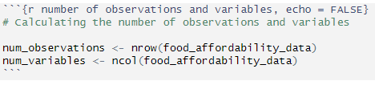

Figure 1. Screenshot of Code

The first two rows of the dataset can be displayed with `str()` in order to view the type of variables within the dataset.

```r
# Displaying the first two rows of the dataset
str(food_affordability_data[1:2,])
```

```
## 'data.frame':    2 obs. of  5 variables:
##  $ Country                                                            : chr  "Albania" "Algeria"
##  $ Continent                                                          : chr  "Europe" "Africa"
##  $ Number of people who cannot afford a healthy diet                  : num  400000 8300000
##  $ Share of the population who cannot afford a healthy diet           : num  12.6 18.7
##  $ Affordability of a healthy diet: ratio of cost to food expenditures: num  32 65
##  - attr(*, "na.action")= 'omit' Named int [1:4] 58 64 96 114
##   ..- attr(*, "names")= chr [1:4] "58" "64" "96" "114"
```

## Data Summary

```r
# Summary statistics for 'Number of people who cannot afford a healthy diet' and 'Affordability of a healthy diet: ratio of cost to food expenditures'
data_summary <- food_affordability_data %>%
  group_by(Continent) %>%
  summarise(
    Mean_Number = format(mean(`Number of people who cannot afford a healthy diet`, na.rm = TRUE), scientific = FALSE),
    Sum_Number = format(sum(`Number of people who cannot afford a healthy diet`, na.rm = TRUE), scientific = FALSE),
    Mean_Share = format(mean(`Share of the population who cannot afford a healthy diet`, na.rm = TRUE), scientific =  FALSE),
    Median_Share = format(median(`Share of the population who cannot afford a healthy diet`, na.rm = TRUE), scientific = FALSE)
  ) %>%
  head(10)

kable(data_summary, caption = "**Summary statistics of the 'Number of people who cannot afford a healthy diet' and 'Share of the population who cannot afford a healthy diet' variables**")
```

**Summary statistics of the ‘Number of people who cannot afford a healthy diet’ and ‘Share of the population who cannot afford a healthy diet’ variables**

| Continent | Mean_Number | Sum_Number | Mean_Share | Median_Share |
| --- | --- | --- | --- | --- |
| Africa | 17862500 | 857400004 | 59.45 | 60.5 |
| Americas | 7258333 | 174199996 | 28.00833 | 26.45 |
| Asia | 48845455 | 1611900030 | 25.17273 | 18 |
| Europe | 1110811 | 41100000 | 8.202703 | 5 |
| Oceania | 700000 | 1400000 | 35 | 35 |

From the summary statistics, the continents of Asia holds the highest number of people unable to afford a healthy diet (at 1.612 billion) which is then followed by Africa (at 857 million), although Africa’s population had a higher mean and median percentage share of the population being impacted compared to Asia’s percentage share. **Please note that certain continents may not be represented accurately due to unavailable data and smaller pools of countries, such as Oceania (i.e. Australia and Fiji) where Fiji has skewed the represented data for the entire region.**

Given that Asia has the largest population unable to afford a healthy diet, we can examine this by further breaking down the numbers by country:

```r
# Break down of 'Number of people who cannot afford a healthy diet' by countries in Asia (sorted by largest population number)
asia_data <- food_affordability_data %>%
  filter(Continent == "Asia") %>%
  select(Country, `Number of people who cannot afford a healthy diet`) %>%
  arrange(desc(`Number of people who cannot afford a healthy diet`))

kable (asia_data, caption = "**Number of People Unable to Afford a Healthy Diet in Asia**")
```

**Number of People Unable to Afford a Healthy Diet in Asia**

| Country | Number of people who cannot afford a healthy diet |
| --- | --- |
| India | 830900030 |
| China | 251300000 |
| Pakistan | 135800000 |
| Indonesia | 127600000 |
| Bangladesh | 87600000 |
| Philippines | 58500000 |
| Syria | 18400000 |
| Nepal | 13100000 |
| Thailand | 13100000 |
| Iraq | 12400000 |
| Japan | 9500000 |
| Vietnam | 9400000 |
| Sri Lanka | 7400000 |
| Turkey | 7400000 |
| Uzbekistan | 5300000 |
| South Korea | 5200000 |
| Laos | 4300000 |
| Tajikistan | 3200000 |
| Kyrgyzstan | 2400000 |
| Israel | 1600000 |
| Armenia | 1500000 |
| Jordan | 1500000 |
| Taiwan | 1100000 |
| Kazakhstan | 1000000 |
| Malaysia | 900000 |
| Mongolia | 800000 |
| Palestine | 300000 |
| Bhutan | 200000 |
| Azerbaijan | 100000 |
| Lebanon | 100000 |
| Cyprus | 0 |
| Maldives | 0 |
| United Arab Emirates | 0 |

The data reveals that India, China and Pakista are the three most affected countries, with a combined total of 1.218 billion people who are unable to afford a healthy diet. This accounts for nearly 76% of the reported affected population in Asia. In contrast, Cyprus, Maldives, and the United Arab Emirates report none being impacted. This could indicate that either negligible numbers are affected, or potential under-reporting or data unavailability for these countries.

## Visualisations

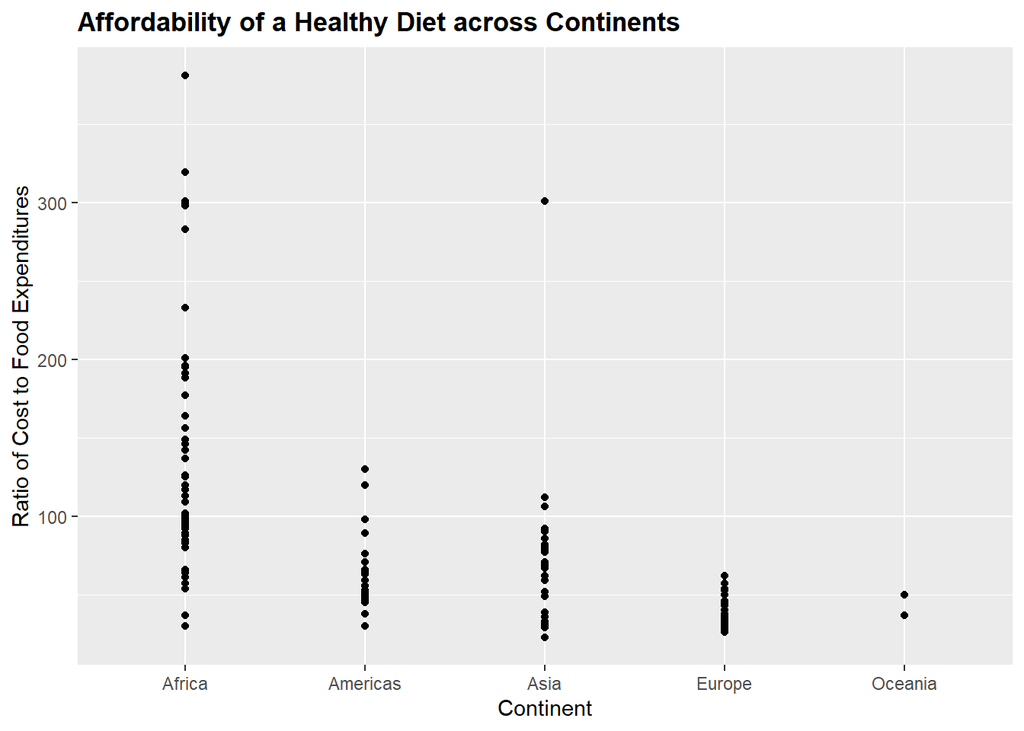

Figure 2. Scatter Plot Visualisation

```r
# Creating the scatter plot for Affordability of a Healthy Diet across Continents
ggplot(food_affordability_data, aes(x = Continent, y = `Affordability of a healthy diet: ratio of cost to food expenditures`)) +
  geom_point() +
  labs(
    title = "Affordability of a Healthy Diet across Continents",
    x = "Continent",
    y =  "Ratio of Cost to Food Expenditures"
  ) +
  theme(plot.title = element_text(face = "bold"))
```

The scatter plot provides a comparison of the affordability of a healthy diet across continents. However, a box plot may be more suitable in providing further insights by highlighting the median, quartiles, and any outliers.

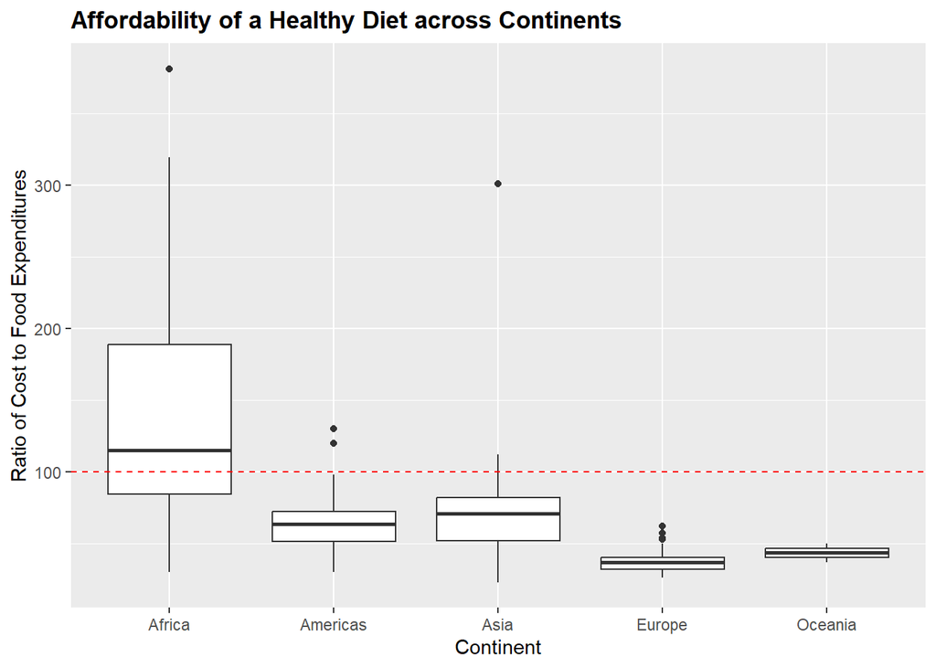

Figure 3. Box Plot Visualisation

```r
# Creating the box plot for Affordability of a Healthy Diet across Continents
ggplot(food_affordability_data, aes(x = Continent, y = `Affordability of a healthy diet: ratio of cost to food expenditures`)) +
  geom_boxplot() +
  geom_hline(yintercept = 100, color = "red", linetype = "dashed") +
  labs(
    title = "Affordability of a Healthy Diet across Continents",
    x = "Continent",
    y =  "Ratio of Cost to Food Expenditures"
  ) +
  theme(plot.title = element_text(face = "bold"))
```

## Conclusion

The project’s research question aimed to determine how much of the global population cannot afford a healthy diet. The findings indicate that approximately 2.686 billion people worldwide lack the means to afford a healthy diet, primarily in Africa and Asia. In Asia, nearly 76% of those affected are located in India, China, and Pakistan, where food budgets are unable to match the total cost required to secure adequate nutrition. With one-third of the world impacted, the FAO’s Director of the Agrifood Economics and Policy Division has highlighted that this represents a structural issue in our agrifood systems, and it will require significant investment in order to address this problem and to achieve the United Nation’s goal of Zero Hunger by 2030 (Emsden (2024)).

## References

BBC. 2023a. “Burundi Country Profile.” https://www.bbc.com/news/world-africa-13085064.

———. 2023b. “Syria Country Profile.” https://www.bbc.com/news/world-middle-east-14703856.

Emsden, C. 2024. “Healthy Diets Remain Unaffordable for a Third of the World’s Population.” Food; Agriculture Organization of the United Nations. https://www.fao.org/newsroom/detail/healthy-diets-remain-unaffordable-for-a-third-of-the-world-s-population/en.

Ritchie, H., P. Rosado, and M. Roser. 2023. “Food Prices.” Our World in Data. https://ourworldindata.org/food-prices.

Shipman, A., A. Smondel, B. Y. Adhinegara, J. W. Diamond, L. G. Vega, M. H. Shahrour, P. Martin, and W. Simpson. 2023. “Global Economy 2023: How Countries Around the World Are Tackling the Cost of Living Crisis.” The Conversation. https://theconversation.com/global-economy-2023-how-countries-around-the-world-are-tackling-the-cost-of-living-crisis-196740.

Whiting, K. 2022. “The Cost-of-Living Crisis Is Having a Global Impact. Here’s What Countries Are Doing to Help.” World Economic Forum. https://www.weforum.org/stories/2022/09/cost-of-living-crisis-global-impact/.